# Risk Factor Analysis

## Outcome Variable

**Outcome Variable:** pers_wast

## Predictor Variables

**Intervention Variable:** parity

**Adjustment Set:**

unadjusted

## Stratifying Variables

The analysis was stratified on these variable(s):

- agecat
- studyid
- country

## Data Summary

| agecat | studyid | country | parity | pers_wast | n_cell | n |
| --- | --- | --- | --- | --- | --- | --- |
| 0-24 months | ki1000304b-SAS-CompFeed | INDIA | 1 | 0 | 123 | 428 |
| 0-24 months | ki1000304b-SAS-CompFeed | INDIA | 1 | 1 | 8 | 428 |
| 0-24 months | ki1000304b-SAS-CompFeed | INDIA | 2 | 0 | 87 | 428 |
| 0-24 months | ki1000304b-SAS-CompFeed | INDIA | 2 | 1 | 8 | 428 |
| 0-24 months | ki1000304b-SAS-CompFeed | INDIA | 3+ | 0 | 186 | 428 |
| 0-24 months | ki1000304b-SAS-CompFeed | INDIA | 3+ | 1 | 16 | 428 |
| 0-24 months | ki1000304b-SAS-FoodSuppl | INDIA | 1 | 0 | 14 | 92 |
| 0-24 months | ki1000304b-SAS-FoodSuppl | INDIA | 1 | 1 | 3 | 92 |
| 0-24 months | ki1000304b-SAS-FoodSuppl | INDIA | 2 | 0 | 18 | 92 |
| 0-24 months | ki1000304b-SAS-FoodSuppl | INDIA | 2 | 1 | 1 | 92 |
| 0-24 months | ki1000304b-SAS-FoodSuppl | INDIA | 3+ | 0 | 43 | 92 |
| 0-24 months | ki1000304b-SAS-FoodSuppl | INDIA | 3+ | 1 | 13 | 92 |
| 0-24 months | ki1017093b-PROVIDE | BANGLADESH | 1 | 0 | 237 | 640 |
| 0-24 months | ki1017093b-PROVIDE | BANGLADESH | 1 | 1 | 4 | 640 |
| 0-24 months | ki1017093b-PROVIDE | BANGLADESH | 2 | 0 | 223 | 640 |
| 0-24 months | ki1017093b-PROVIDE | BANGLADESH | 2 | 1 | 4 | 640 |
| 0-24 months | ki1017093b-PROVIDE | BANGLADESH | 3+ | 0 | 165 | 640 |
| 0-24 months | ki1017093b-PROVIDE | BANGLADESH | 3+ | 1 | 7 | 640 |
| 0-24 months | ki1066203-TanzaniaChild2 | TANZANIA, UNITED REPUBLIC OF | 1 | 0 | 710 | 2132 |
| 0-24 months | ki1066203-TanzaniaChild2 | TANZANIA, UNITED REPUBLIC OF | 1 | 1 | 18 | 2132 |
| 0-24 months | ki1066203-TanzaniaChild2 | TANZANIA, UNITED REPUBLIC OF | 2 | 0 | 683 | 2132 |
| 0-24 months | ki1066203-TanzaniaChild2 | TANZANIA, UNITED REPUBLIC OF | 2 | 1 | 20 | 2132 |
| 0-24 months | ki1066203-TanzaniaChild2 | TANZANIA, UNITED REPUBLIC OF | 3+ | 0 | 682 | 2132 |
| 0-24 months | ki1066203-TanzaniaChild2 | TANZANIA, UNITED REPUBLIC OF | 3+ | 1 | 19 | 2132 |
| 0-24 months | ki1101329-Keneba | GAMBIA | 1 | 0 | 220 | 1850 |
| 0-24 months | ki1101329-Keneba | GAMBIA | 1 | 1 | 9 | 1850 |
| 0-24 months | ki1101329-Keneba | GAMBIA | 2 | 0 | 190 | 1850 |
| 0-24 months | ki1101329-Keneba | GAMBIA | 2 | 1 | 9 | 1850 |
| 0-24 months | ki1101329-Keneba | GAMBIA | 3+ | 0 | 1350 | 1850 |
| 0-24 months | ki1101329-Keneba | GAMBIA | 3+ | 1 | 72 | 1850 |

[output cut: 144 more lines]

The following strata were considered:

- agecat: 0-24 months, studyid: ki1000304b-SAS-CompFeed, country: INDIA
- agecat: 0-24 months, studyid: ki1000304b-SAS-FoodSuppl, country: INDIA
- agecat: 0-24 months, studyid: ki1017093b-PROVIDE, country: BANGLADESH
- agecat: 0-24 months, studyid: ki1066203-TanzaniaChild2, country: TANZANIA, UNITED REPUBLIC OF
- agecat: 0-24 months, studyid: ki1101329-Keneba, country: GAMBIA
- agecat: 0-24 months, studyid: ki1113344-GMS-Nepal, country: NEPAL
- agecat: 0-24 months, studyid: ki1126311-ZVITAMBO, country: ZIMBABWE
- agecat: 0-24 months, studyid: ki1135781-COHORTS, country: GUATEMALA
- agecat: 0-24 months, studyid: ki1135781-COHORTS, country: INDIA
- agecat: 0-24 months, studyid: ki1135781-COHORTS, country: PHILIPPINES
- agecat: 0-24 months, studyid: kiGH5241-JiVitA-3, country: BANGLADESH
- agecat: 0-6 months, studyid: ki1017093b-PROVIDE, country: BANGLADESH
- agecat: 0-6 months, studyid: ki1066203-TanzaniaChild2, country: TANZANIA, UNITED REPUBLIC OF
- agecat: 0-6 months, studyid: ki1101329-Keneba, country: GAMBIA
- agecat: 0-6 months, studyid: ki1113344-GMS-Nepal, country: NEPAL
- agecat: 0-6 months, studyid: ki1126311-ZVITAMBO, country: ZIMBABWE
- agecat: 0-6 months, studyid: ki1135781-COHORTS, country: PHILIPPINES
- agecat: 0-6 months, studyid: kiGH5241-JiVitA-3, country: BANGLADESH
- agecat: 6-24 months, studyid: ki1000304b-SAS-CompFeed, country: INDIA
- agecat: 6-24 months, studyid: ki1000304b-SAS-FoodSuppl, country: INDIA
- agecat: 6-24 months, studyid: ki1017093b-PROVIDE, country: BANGLADESH
- agecat: 6-24 months, studyid: ki1066203-TanzaniaChild2, country: TANZANIA, UNITED REPUBLIC OF
- agecat: 6-24 months, studyid: ki1101329-Keneba, country: GAMBIA
- agecat: 6-24 months, studyid: ki1113344-GMS-Nepal, country: NEPAL
- agecat: 6-24 months, studyid: ki1126311-ZVITAMBO, country: ZIMBABWE
- agecat: 6-24 months, studyid: ki1135781-COHORTS, country: GUATEMALA
- agecat: 6-24 months, studyid: ki1135781-COHORTS, country: INDIA
- agecat: 6-24 months, studyid: ki1135781-COHORTS, country: PHILIPPINES
- agecat: 6-24 months, studyid: kiGH5241-JiVitA-3, country: BANGLADESH

### Dropped Strata

Some strata were dropped due to rare outcomes:

- agecat: 0-24 months, studyid: ki1000304b-SAS-FoodSuppl, country: INDIA
- agecat: 0-24 months, studyid: ki1017093b-PROVIDE, country: BANGLADESH
- agecat: 0-24 months, studyid: ki1135781-COHORTS, country: GUATEMALA
- agecat: 0-6 months, studyid: ki1017093b-PROVIDE, country: BANGLADESH
- agecat: 0-6 months, studyid: ki1101329-Keneba, country: GAMBIA
- agecat: 0-6 months, studyid: ki1126311-ZVITAMBO, country: ZIMBABWE
- agecat: 0-6 months, studyid: kiGH5241-JiVitA-3, country: BANGLADESH
- agecat: 6-24 months, studyid: ki1000304b-SAS-FoodSuppl, country: INDIA
- agecat: 6-24 months, studyid: ki1017093b-PROVIDE, country: BANGLADESH
- agecat: 6-24 months, studyid: ki1135781-COHORTS, country: GUATEMALA

## Methods Detail

We’re interested in the causal parameters $E[Y_a]$ for all values of $a \in \mathcal{A}$. These parameters represent the mean outcome if, possibly contrary to fact, we intervened to set all units to have $A=a$. Under the randomization and positivity assumptions, these are identified by the statistical parameters $\psi_a=E_W[E_{Y|A,W}(Y|A=a,W)]$. In addition, we’re interested in the mean of $Y$, $E[Y]$ under no intervention (the observed mean). We will estimate these parameters by using SuperLearner to fit the relevant likelihood factors – $E_{Y|A,W}(Y|A=a,W)$ and $p(A=a|W)$, and then updating our likelihood fit using a joint TMLE.

For unadjusted analyses ($W=\{\}$), initial likelihoods were estimated using Lrnr_glm to estimate the simple $E(Y|A)$ and Lrnr_mean to estimate $p(A)$. For adjusted analyses, a small library containing Lrnr_glmnet, Lrnr_xgboost, and Lrnr_mean was used.

Having estimated these parameters, we will then use the delta method to estimate relative risks and attributable risks relative to a prespecified baseline level of $A$.

# Results Detail

## Results Plots

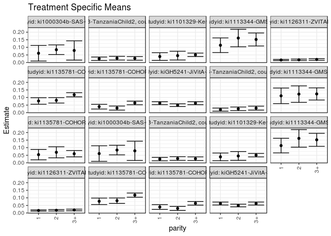

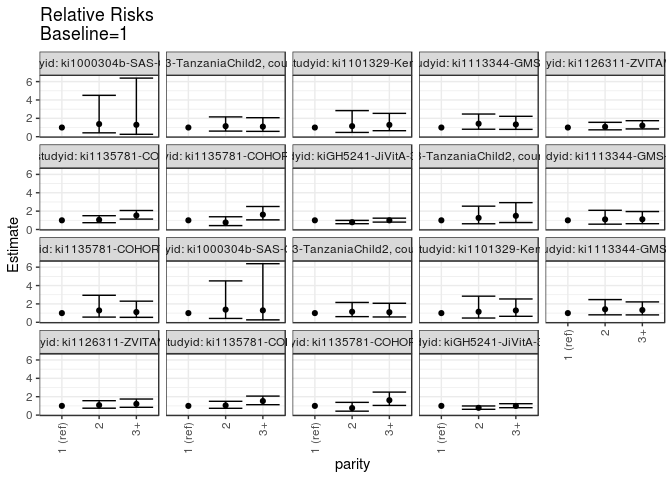

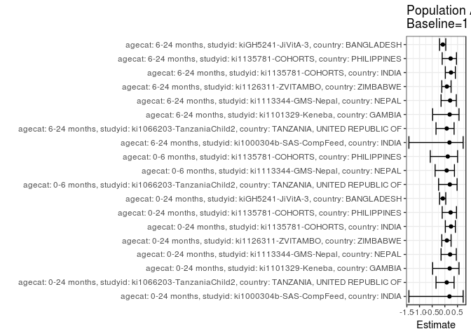

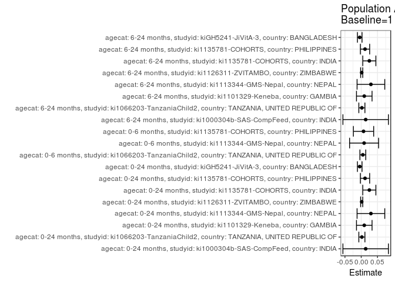

## Results Table

### Parameter: TSM

| agecat | studyid | country | intervention_level | baseline_level | estimate | ci_lower | ci_upper |
| --- | --- | --- | --- | --- | --- | --- | --- |
| 0-24 months | ki1000304b-SAS-CompFeed | INDIA | 1 | NA | 0.0610687 | 0.0096368 | 0.1125006 |
| 0-24 months | ki1000304b-SAS-CompFeed | INDIA | 2 | NA | 0.0842105 | 0.0525539 | 0.1158672 |
| 0-24 months | ki1000304b-SAS-CompFeed | INDIA | 3+ | NA | 0.0792079 | 0.0156221 | 0.1427938 |
| 0-24 months | ki1066203-TanzaniaChild2 | TANZANIA, UNITED REPUBLIC OF | 1 | NA | 0.0247253 | 0.0134424 | 0.0360081 |
| 0-24 months | ki1066203-TanzaniaChild2 | TANZANIA, UNITED REPUBLIC OF | 2 | NA | 0.0284495 | 0.0161569 | 0.0407421 |
| 0-24 months | ki1066203-TanzaniaChild2 | TANZANIA, UNITED REPUBLIC OF | 3+ | NA | 0.0271041 | 0.0150803 | 0.0391279 |
| 0-24 months | ki1101329-Keneba | GAMBIA | 1 | NA | 0.0393013 | 0.0141277 | 0.0644749 |
| 0-24 months | ki1101329-Keneba | GAMBIA | 2 | NA | 0.0452261 | 0.0163470 | 0.0741053 |
| 0-24 months | ki1101329-Keneba | GAMBIA | 3+ | NA | 0.0506329 | 0.0392344 | 0.0620315 |
| 0-24 months | ki1113344-GMS-Nepal | NEPAL | 1 | NA | 0.1137725 | 0.0655723 | 0.1619726 |
| 0-24 months | ki1113344-GMS-Nepal | NEPAL | 2 | NA | 0.1612903 | 0.1033395 | 0.2192411 |
| 0-24 months | ki1113344-GMS-Nepal | NEPAL | 3+ | NA | 0.1518519 | 0.1090089 | 0.1946948 |
| 0-24 months | ki1126311-ZVITAMBO | ZIMBABWE | 1 | NA | 0.0164332 | 0.0123431 | 0.0205233 |
| 0-24 months | ki1126311-ZVITAMBO | ZIMBABWE | 2 | NA | 0.0177886 | 0.0129499 | 0.0226274 |
| 0-24 months | ki1126311-ZVITAMBO | ZIMBABWE | 3+ | NA | 0.0199782 | 0.0147511 | 0.0252053 |
| 0-24 months | ki1135781-COHORTS | INDIA | 1 | NA | 0.0771812 | 0.0557523 | 0.0986101 |
| 0-24 months | ki1135781-COHORTS | INDIA | 2 | NA | 0.0812918 | 0.0634153 | 0.0991683 |
| 0-24 months | ki1135781-COHORTS | INDIA | 3+ | NA | 0.1180390 | 0.1042405 | 0.1318376 |
| 0-24 months | ki1135781-COHORTS | PHILIPPINES | 1 | NA | 0.0395387 | 0.0240333 | 0.0550441 |
| 0-24 months | ki1135781-COHORTS | PHILIPPINES | 2 | NA | 0.0303030 | 0.0168830 | 0.0437230 |
| 0-24 months | ki1135781-COHORTS | PHILIPPINES | 3+ | NA | 0.0640457 | 0.0519597 | 0.0761316 |
| 0-24 months | kiGH5241-JiVitA-3 | BANGLADESH | 1 | NA | 0.0625869 | 0.0529350 | 0.0722388 |
| 0-24 months | kiGH5241-JiVitA-3 | BANGLADESH | 2 | NA | 0.0494197 | 0.0406855 | 0.0581539 |
| 0-24 months | kiGH5241-JiVitA-3 | BANGLADESH | 3+ | NA | 0.0624717 | 0.0525536 | 0.0723898 |
| 0-6 months | ki1066203-TanzaniaChild2 | TANZANIA, UNITED REPUBLIC OF | 1 | NA | 0.0201439 | 0.0096963 | 0.0305915 |
| 0-6 months | ki1066203-TanzaniaChild2 | TANZANIA, UNITED REPUBLIC OF | 2 | NA | 0.0254111 | 0.0134832 | 0.0373390 |
| 0-6 months | ki1066203-TanzaniaChild2 | TANZANIA, UNITED REPUBLIC OF | 3+ | NA | 0.0300300 | 0.0170650 | 0.0429951 |
| 0-6 months | ki1113344-GMS-Nepal | NEPAL | 1 | NA | 0.1111111 | 0.0597339 | 0.1624883 |
| 0-6 months | ki1113344-GMS-Nepal | NEPAL | 2 | NA | 0.1223022 | 0.0677852 | 0.1768191 |
| 0-6 months | ki1113344-GMS-Nepal | NEPAL | 3+ | NA | 0.1235521 | 0.0834389 | 0.1636653 |
| 0-6 months | ki1135781-COHORTS | PHILIPPINES | 1 | NA | 0.0538922 | 0.0196251 | 0.0881594 |
| 0-6 months | ki1135781-COHORTS | PHILIPPINES | 2 | NA | 0.0695187 | 0.0330444 | 0.1059930 |
| 0-6 months | ki1135781-COHORTS | PHILIPPINES | 3+ | NA | 0.0601202 | 0.0392514 | 0.0809891 |
| 6-24 months | ki1000304b-SAS-CompFeed | INDIA | 1 | NA | 0.0610687 | 0.0096368 | 0.1125006 |
| 6-24 months | ki1000304b-SAS-CompFeed | INDIA | 2 | NA | 0.0842105 | 0.0525539 | 0.1158672 |
| 6-24 months | ki1000304b-SAS-CompFeed | INDIA | 3+ | NA | 0.0792079 | 0.0156221 | 0.1427938 |
| 6-24 months | ki1066203-TanzaniaChild2 | TANZANIA, UNITED REPUBLIC OF | 1 | NA | 0.0247253 | 0.0134424 | 0.0360081 |
| 6-24 months | ki1066203-TanzaniaChild2 | TANZANIA, UNITED REPUBLIC OF | 2 | NA | 0.0284495 | 0.0161569 | 0.0407421 |
| 6-24 months | ki1066203-TanzaniaChild2 | TANZANIA, UNITED REPUBLIC OF | 3+ | NA | 0.0271041 | 0.0150803 | 0.0391279 |
| 6-24 months | ki1101329-Keneba | GAMBIA | 1 | NA | 0.0393013 | 0.0141277 | 0.0644749 |
| 6-24 months | ki1101329-Keneba | GAMBIA | 2 | NA | 0.0452261 | 0.0163470 | 0.0741053 |
| 6-24 months | ki1101329-Keneba | GAMBIA | 3+ | NA | 0.0506329 | 0.0392344 | 0.0620315 |
| 6-24 months | ki1113344-GMS-Nepal | NEPAL | 1 | NA | 0.1137725 | 0.0655723 | 0.1619726 |
| 6-24 months | ki1113344-GMS-Nepal | NEPAL | 2 | NA | 0.1612903 | 0.1033395 | 0.2192411 |
| 6-24 months | ki1113344-GMS-Nepal | NEPAL | 3+ | NA | 0.1518519 | 0.1090089 | 0.1946948 |
| 6-24 months | ki1126311-ZVITAMBO | ZIMBABWE | 1 | NA | 0.0164332 | 0.0123431 | 0.0205233 |
| 6-24 months | ki1126311-ZVITAMBO | ZIMBABWE | 2 | NA | 0.0177886 | 0.0129499 | 0.0226274 |
| 6-24 months | ki1126311-ZVITAMBO | ZIMBABWE | 3+ | NA | 0.0199782 | 0.0147511 | 0.0252053 |
| 6-24 months | ki1135781-COHORTS | INDIA | 1 | NA | 0.0771812 | 0.0557523 | 0.0986101 |
| 6-24 months | ki1135781-COHORTS | INDIA | 2 | NA | 0.0812918 | 0.0634153 | 0.0991683 |
| 6-24 months | ki1135781-COHORTS | INDIA | 3+ | NA | 0.1180390 | 0.1042405 | 0.1318376 |
| 6-24 months | ki1135781-COHORTS | PHILIPPINES | 1 | NA | 0.0395387 | 0.0240333 | 0.0550441 |
| 6-24 months | ki1135781-COHORTS | PHILIPPINES | 2 | NA | 0.0303030 | 0.0168830 | 0.0437230 |
| 6-24 months | ki1135781-COHORTS | PHILIPPINES | 3+ | NA | 0.0640457 | 0.0519597 | 0.0761316 |
| 6-24 months | kiGH5241-JiVitA-3 | BANGLADESH | 1 | NA | 0.0625869 | 0.0529350 | 0.0722388 |
| 6-24 months | kiGH5241-JiVitA-3 | BANGLADESH | 2 | NA | 0.0494197 | 0.0406855 | 0.0581539 |
| 6-24 months | kiGH5241-JiVitA-3 | BANGLADESH | 3+ | NA | 0.0624717 | 0.0525536 | 0.0723898 |

### Parameter: E(Y)

| agecat | studyid | country | intervention_level | baseline_level | estimate | ci_lower | ci_upper |
| --- | --- | --- | --- | --- | --- | --- | --- |
| 0-24 months | ki1000304b-SAS-CompFeed | INDIA | NA | NA | 0.0747664 | 0.0516226 | 0.0979101 |
| 0-24 months | ki1066203-TanzaniaChild2 | TANZANIA, UNITED REPUBLIC OF | NA | NA | 0.0267355 | 0.0198866 | 0.0335843 |
| 0-24 months | ki1101329-Keneba | GAMBIA | NA | NA | 0.0486486 | 0.0388428 | 0.0584545 |
| 0-24 months | ki1113344-GMS-Nepal | NEPAL | NA | NA | 0.1435811 | 0.1153098 | 0.1718524 |
| 0-24 months | ki1126311-ZVITAMBO | ZIMBABWE | NA | NA | 0.0178954 | 0.0152055 | 0.0205853 |
| 0-24 months | ki1135781-COHORTS | INDIA | NA | NA | 0.1020862 | 0.0921879 | 0.1119845 |
| 0-24 months | ki1135781-COHORTS | PHILIPPINES | NA | NA | 0.0512273 | 0.0430760 | 0.0593786 |
| 0-24 months | kiGH5241-JiVitA-3 | BANGLADESH | NA | NA | 0.0580196 | 0.0522035 | 0.0638357 |
| 0-6 months | ki1066203-TanzaniaChild2 | TANZANIA, UNITED REPUBLIC OF | NA | NA | 0.0251232 | 0.0183136 | 0.0319327 |
| 0-6 months | ki1113344-GMS-Nepal | NEPAL | NA | NA | 0.1199262 | 0.0925504 | 0.1473020 |
| 0-6 months | ki1135781-COHORTS | PHILIPPINES | NA | NA | 0.0609613 | 0.0448957 | 0.0770269 |
| 6-24 months | ki1000304b-SAS-CompFeed | INDIA | NA | NA | 0.0747664 | 0.0516226 | 0.0979101 |
| 6-24 months | ki1066203-TanzaniaChild2 | TANZANIA, UNITED REPUBLIC OF | NA | NA | 0.0267355 | 0.0198866 | 0.0335843 |
| 6-24 months | ki1101329-Keneba | GAMBIA | NA | NA | 0.0486486 | 0.0388428 | 0.0584545 |
| 6-24 months | ki1113344-GMS-Nepal | NEPAL | NA | NA | 0.1435811 | 0.1153098 | 0.1718524 |
| 6-24 months | ki1126311-ZVITAMBO | ZIMBABWE | NA | NA | 0.0178954 | 0.0152055 | 0.0205853 |
| 6-24 months | ki1135781-COHORTS | INDIA | NA | NA | 0.1020862 | 0.0921879 | 0.1119845 |
| 6-24 months | ki1135781-COHORTS | PHILIPPINES | NA | NA | 0.0512273 | 0.0430760 | 0.0593786 |
| 6-24 months | kiGH5241-JiVitA-3 | BANGLADESH | NA | NA | 0.0580196 | 0.0522035 | 0.0638357 |

### Parameter: RR

| agecat | studyid | country | intervention_level | baseline_level | estimate | ci_lower | ci_upper |
| --- | --- | --- | --- | --- | --- | --- | --- |
| 0-24 months | ki1000304b-SAS-CompFeed | INDIA | 1 | 1 | 1.0000000 | 1.0000000 | 1.0000000 |
| 0-24 months | ki1000304b-SAS-CompFeed | INDIA | 2 | 1 | 1.3789474 | 0.4220832 | 4.5050263 |
| 0-24 months | ki1000304b-SAS-CompFeed | INDIA | 3+ | 1 | 1.2970297 | 0.2637119 | 6.3792566 |
| 0-24 months | ki1066203-TanzaniaChild2 | TANZANIA, UNITED REPUBLIC OF | 1 | 1 | 1.0000000 | 1.0000000 | 1.0000000 |
| 0-24 months | ki1066203-TanzaniaChild2 | TANZANIA, UNITED REPUBLIC OF | 2 | 1 | 1.1506243 | 0.6137724 | 2.1570475 |
| 0-24 months | ki1066203-TanzaniaChild2 | TANZANIA, UNITED REPUBLIC OF | 3+ | 1 | 1.0962118 | 0.5800975 | 2.0715142 |
| 0-24 months | ki1101329-Keneba | GAMBIA | 1 | 1 | 1.0000000 | 1.0000000 | 1.0000000 |
| 0-24 months | ki1101329-Keneba | GAMBIA | 2 | 1 | 1.1507536 | 0.4657865 | 2.8430063 |
| 0-24 months | ki1101329-Keneba | GAMBIA | 3+ | 1 | 1.2883261 | 0.6533823 | 2.5402955 |
| 0-24 months | ki1113344-GMS-Nepal | NEPAL | 1 | 1 | 1.0000000 | 1.0000000 | 1.0000000 |
| 0-24 months | ki1113344-GMS-Nepal | NEPAL | 2 | 1 | 1.4176570 | 0.8134344 | 2.4706989 |
| 0-24 months | ki1113344-GMS-Nepal | NEPAL | 3+ | 1 | 1.3346979 | 0.8022801 | 2.2204443 |
| 0-24 months | ki1126311-ZVITAMBO | ZIMBABWE | 1 | 1 | 1.0000000 | 1.0000000 | 1.0000000 |
| 0-24 months | ki1126311-ZVITAMBO | ZIMBABWE | 2 | 1 | 1.0824818 | 0.7486825 | 1.5651053 |
| 0-24 months | ki1126311-ZVITAMBO | ZIMBABWE | 3+ | 1 | 1.2157229 | 0.8472369 | 1.7444733 |
| 0-24 months | ki1135781-COHORTS | INDIA | 1 | 1 | 1.0000000 | 1.0000000 | 1.0000000 |
| 0-24 months | ki1135781-COHORTS | INDIA | 2 | 1 | 1.0532584 | 0.7391217 | 1.5009075 |
| 0-24 months | ki1135781-COHORTS | INDIA | 3+ | 1 | 1.5293752 | 1.1315744 | 2.0670215 |
| 0-24 months | ki1135781-COHORTS | PHILIPPINES | 1 | 1 | 1.0000000 | 1.0000000 | 1.0000000 |
| 0-24 months | ki1135781-COHORTS | PHILIPPINES | 2 | 1 | 0.7664141 | 0.4241932 | 1.3847242 |
| 0-24 months | ki1135781-COHORTS | PHILIPPINES | 3+ | 1 | 1.6198214 | 1.0482449 | 2.5030614 |
| 0-24 months | kiGH5241-JiVitA-3 | BANGLADESH | 1 | 1 | 1.0000000 | 1.0000000 | 1.0000000 |
| 0-24 months | kiGH5241-JiVitA-3 | BANGLADESH | 2 | 1 | 0.7896169 | 0.6299457 | 0.9897597 |
| 0-24 months | kiGH5241-JiVitA-3 | BANGLADESH | 3+ | 1 | 0.9981590 | 0.8056770 | 1.2366264 |
| 0-6 months | ki1066203-TanzaniaChild2 | TANZANIA, UNITED REPUBLIC OF | 1 | 1 | 1.0000000 | 1.0000000 | 1.0000000 |
| 0-6 months | ki1066203-TanzaniaChild2 | TANZANIA, UNITED REPUBLIC OF | 2 | 1 | 1.2614777 | 0.6267314 | 2.5390878 |
| 0-6 months | ki1066203-TanzaniaChild2 | TANZANIA, UNITED REPUBLIC OF | 3+ | 1 | 1.4907765 | 0.7591695 | 2.9274287 |
| 0-6 months | ki1113344-GMS-Nepal | NEPAL | 1 | 1 | 1.0000000 | 1.0000000 | 1.0000000 |
| 0-6 months | ki1113344-GMS-Nepal | NEPAL | 2 | 1 | 1.1007194 | 0.5790866 | 2.0922316 |
| 0-6 months | ki1113344-GMS-Nepal | NEPAL | 3+ | 1 | 1.1119691 | 0.6320034 | 1.9564378 |
| 0-6 months | ki1135781-COHORTS | PHILIPPINES | 1 | 1 | 1.0000000 | 1.0000000 | 1.0000000 |
| 0-6 months | ki1135781-COHORTS | PHILIPPINES | 2 | 1 | 1.2899584 | 0.5656642 | 2.9416615 |
| 0-6 months | ki1135781-COHORTS | PHILIPPINES | 3+ | 1 | 1.1155645 | 0.5406060 | 2.3020166 |
| 6-24 months | ki1000304b-SAS-CompFeed | INDIA | 1 | 1 | 1.0000000 | 1.0000000 | 1.0000000 |
| 6-24 months | ki1000304b-SAS-CompFeed | INDIA | 2 | 1 | 1.3789474 | 0.4220832 | 4.5050263 |
| 6-24 months | ki1000304b-SAS-CompFeed | INDIA | 3+ | 1 | 1.2970297 | 0.2637119 | 6.3792566 |
| 6-24 months | ki1066203-TanzaniaChild2 | TANZANIA, UNITED REPUBLIC OF | 1 | 1 | 1.0000000 | 1.0000000 | 1.0000000 |
| 6-24 months | ki1066203-TanzaniaChild2 | TANZANIA, UNITED REPUBLIC OF | 2 | 1 | 1.1506243 | 0.6137724 | 2.1570475 |
| 6-24 months | ki1066203-TanzaniaChild2 | TANZANIA, UNITED REPUBLIC OF | 3+ | 1 | 1.0962118 | 0.5800975 | 2.0715142 |
| 6-24 months | ki1101329-Keneba | GAMBIA | 1 | 1 | 1.0000000 | 1.0000000 | 1.0000000 |
| 6-24 months | ki1101329-Keneba | GAMBIA | 2 | 1 | 1.1507536 | 0.4657865 | 2.8430063 |
| 6-24 months | ki1101329-Keneba | GAMBIA | 3+ | 1 | 1.2883261 | 0.6533823 | 2.5402955 |
| 6-24 months | ki1113344-GMS-Nepal | NEPAL | 1 | 1 | 1.0000000 | 1.0000000 | 1.0000000 |
| 6-24 months | ki1113344-GMS-Nepal | NEPAL | 2 | 1 | 1.4176570 | 0.8134344 | 2.4706989 |
| 6-24 months | ki1113344-GMS-Nepal | NEPAL | 3+ | 1 | 1.3346979 | 0.8022801 | 2.2204443 |
| 6-24 months | ki1126311-ZVITAMBO | ZIMBABWE | 1 | 1 | 1.0000000 | 1.0000000 | 1.0000000 |
| 6-24 months | ki1126311-ZVITAMBO | ZIMBABWE | 2 | 1 | 1.0824818 | 0.7486825 | 1.5651053 |
| 6-24 months | ki1126311-ZVITAMBO | ZIMBABWE | 3+ | 1 | 1.2157229 | 0.8472369 | 1.7444733 |
| 6-24 months | ki1135781-COHORTS | INDIA | 1 | 1 | 1.0000000 | 1.0000000 | 1.0000000 |
| 6-24 months | ki1135781-COHORTS | INDIA | 2 | 1 | 1.0532584 | 0.7391217 | 1.5009075 |
| 6-24 months | ki1135781-COHORTS | INDIA | 3+ | 1 | 1.5293752 | 1.1315744 | 2.0670215 |
| 6-24 months | ki1135781-COHORTS | PHILIPPINES | 1 | 1 | 1.0000000 | 1.0000000 | 1.0000000 |
| 6-24 months | ki1135781-COHORTS | PHILIPPINES | 2 | 1 | 0.7664141 | 0.4241932 | 1.3847242 |
| 6-24 months | ki1135781-COHORTS | PHILIPPINES | 3+ | 1 | 1.6198214 | 1.0482449 | 2.5030614 |
| 6-24 months | kiGH5241-JiVitA-3 | BANGLADESH | 1 | 1 | 1.0000000 | 1.0000000 | 1.0000000 |
| 6-24 months | kiGH5241-JiVitA-3 | BANGLADESH | 2 | 1 | 0.7896169 | 0.6299457 | 0.9897597 |
| 6-24 months | kiGH5241-JiVitA-3 | BANGLADESH | 3+ | 1 | 0.9981590 | 0.8056770 | 1.2366264 |

### Parameter: PAR

| agecat | studyid | country | intervention_level | baseline_level | estimate | ci_lower | ci_upper |
| --- | --- | --- | --- | --- | --- | --- | --- |
| 0-24 months | ki1000304b-SAS-CompFeed | INDIA | 1 | NA | 0.0136977 | -0.0562390 | 0.0836343 |
| 0-24 months | ki1066203-TanzaniaChild2 | TANZANIA, UNITED REPUBLIC OF | 1 | NA | 0.0020102 | -0.0073317 | 0.0113521 |
| 0-24 months | ki1101329-Keneba | GAMBIA | 1 | NA | 0.0093473 | -0.0145896 | 0.0332843 |
| 0-24 months | ki1113344-GMS-Nepal | NEPAL | 1 | NA | 0.0298086 | -0.0127562 | 0.0723735 |
| 0-24 months | ki1126311-ZVITAMBO | ZIMBABWE | 1 | NA | 0.0014622 | -0.0018021 | 0.0047265 |
| 0-24 months | ki1135781-COHORTS | INDIA | 1 | NA | 0.0249050 | 0.0047825 | 0.0450276 |
| 0-24 months | ki1135781-COHORTS | PHILIPPINES | 1 | NA | 0.0116886 | -0.0025603 | 0.0259375 |
| 0-24 months | kiGH5241-JiVitA-3 | BANGLADESH | 1 | NA | -0.0045673 | -0.0116588 | 0.0025241 |
| 0-6 months | ki1066203-TanzaniaChild2 | TANZANIA, UNITED REPUBLIC OF | 1 | NA | 0.0049793 | -0.0040086 | 0.0139672 |
| 0-6 months | ki1113344-GMS-Nepal | NEPAL | 1 | NA | 0.0088151 | -0.0357545 | 0.0533847 |
| 0-6 months | ki1135781-COHORTS | PHILIPPINES | 1 | NA | 0.0070691 | -0.0241168 | 0.0382550 |
| 6-24 months | ki1000304b-SAS-CompFeed | INDIA | 1 | NA | 0.0136977 | -0.0562390 | 0.0836343 |
| 6-24 months | ki1066203-TanzaniaChild2 | TANZANIA, UNITED REPUBLIC OF | 1 | NA | 0.0020102 | -0.0073317 | 0.0113521 |
| 6-24 months | ki1101329-Keneba | GAMBIA | 1 | NA | 0.0093473 | -0.0145896 | 0.0332843 |
| 6-24 months | ki1113344-GMS-Nepal | NEPAL | 1 | NA | 0.0298086 | -0.0127562 | 0.0723735 |
| 6-24 months | ki1126311-ZVITAMBO | ZIMBABWE | 1 | NA | 0.0014622 | -0.0018021 | 0.0047265 |
| 6-24 months | ki1135781-COHORTS | INDIA | 1 | NA | 0.0249050 | 0.0047825 | 0.0450276 |
| 6-24 months | ki1135781-COHORTS | PHILIPPINES | 1 | NA | 0.0116886 | -0.0025603 | 0.0259375 |
| 6-24 months | kiGH5241-JiVitA-3 | BANGLADESH | 1 | NA | -0.0045673 | -0.0116588 | 0.0025241 |

### Parameter: PAF

| agecat | studyid | country | intervention_level | baseline_level | estimate | ci_lower | ci_upper |
| --- | --- | --- | --- | --- | --- | --- | --- |
| 0-24 months | ki1000304b-SAS-CompFeed | INDIA | 1 | NA | 0.1832061 | -1.4199988 | 0.7243171 |
| 0-24 months | ki1066203-TanzaniaChild2 | TANZANIA, UNITED REPUBLIC OF | 1 | NA | 0.0751880 | -0.3486669 | 0.3658350 |
| 0-24 months | ki1101329-Keneba | GAMBIA | 1 | NA | 0.1921396 | -0.4828459 | 0.5598744 |
| 0-24 months | ki1113344-GMS-Nepal | NEPAL | 1 | NA | 0.2076083 | -0.1488967 | 0.4534891 |
| 0-24 months | ki1126311-ZVITAMBO | ZIMBABWE | 1 | NA | 0.0817094 | -0.1195925 | 0.2468174 |
| 0-24 months | ki1135781-COHORTS | INDIA | 1 | NA | 0.2439606 | 0.0202944 | 0.4165640 |
| 0-24 months | ki1135781-COHORTS | PHILIPPINES | 1 | NA | 0.2281713 | -0.1035805 | 0.4601939 |
| 0-24 months | kiGH5241-JiVitA-3 | BANGLADESH | 1 | NA | -0.0787204 | -0.2074543 | 0.0362883 |
| 0-6 months | ki1066203-TanzaniaChild2 | TANZANIA, UNITED REPUBLIC OF | 1 | NA | 0.1981944 | -0.2466347 | 0.4842978 |
| 0-6 months | ki1113344-GMS-Nepal | NEPAL | 1 | NA | 0.0735043 | -0.3833037 | 0.3794607 |
| 0-6 months | ki1135781-COHORTS | PHILIPPINES | 1 | NA | 0.1159604 | -0.5753898 | 0.5039158 |
| 6-24 months | ki1000304b-SAS-CompFeed | INDIA | 1 | NA | 0.1832061 | -1.4199988 | 0.7243171 |
| 6-24 months | ki1066203-TanzaniaChild2 | TANZANIA, UNITED REPUBLIC OF | 1 | NA | 0.0751880 | -0.3486669 | 0.3658350 |
| 6-24 months | ki1101329-Keneba | GAMBIA | 1 | NA | 0.1921396 | -0.4828459 | 0.5598744 |
| 6-24 months | ki1113344-GMS-Nepal | NEPAL | 1 | NA | 0.2076083 | -0.1488967 | 0.4534891 |
| 6-24 months | ki1126311-ZVITAMBO | ZIMBABWE | 1 | NA | 0.0817094 | -0.1195925 | 0.2468174 |
| 6-24 months | ki1135781-COHORTS | INDIA | 1 | NA | 0.2439606 | 0.0202944 | 0.4165640 |
| 6-24 months | ki1135781-COHORTS | PHILIPPINES | 1 | NA | 0.2281713 | -0.1035805 | 0.4601939 |
| 6-24 months | kiGH5241-JiVitA-3 | BANGLADESH | 1 | NA | -0.0787204 | -0.2074543 | 0.0362883 |